# FACTORS INFLUENCING JOB SATISFACTION

# PART 1 - INTRODUCTION/DESCRIPTIVE STATISTICS

# The Determinants of Job Satisfaction

## 1.0 Background

# Introduction

This analysis examines the factors that influence employee job satisfaction. The literature on job satisfaction is extensive, with scholars offering different perspectives on the determinants of employee satisfaction (Cornelißen, 2006). This interest reflects the widely held view that employees are an organisation’s most valuable resource. Meier and Spector (2015, p. 1) define job satisfaction as “a person’s overall evaluation of his or her job as favourable or unfavourable.” Previous research has consistently established a positive relationship between employee job satisfaction and organisational performance (Meier and Spector, 2015; Sainju, Hartwell and Edwards, 2021). Conversely, low levels of job satisfaction contribute to higher employee turnover (Pablo, 2023), while the financial and operational costs of replacing employees can place a significant burden on organisations (Kim et al., 2023).

Employee attrition has become an increasing challenge for organisations. One possible explanation is the rapid advancement of digital technologies, together with the growth of the gig economy, which accelerated following the COVID-19 pandemic. These developments have expanded employment opportunities, giving employees greater flexibility to change jobs. Consequently, organisations face increasing pressure to attract and retain skilled employees. Understanding the key determinants of job satisfaction is therefore essential for managers seeking to develop effective retention strategies. This study addresses the following research question: What are the determinants of job satisfaction?

# Dataset

This study uses a teaching dataset derived from an abridged version of the 2004 Workplace Employment Relations Survey (WERS) compiled by Stokes and Forth (2008) and accessed through the UK Data Service Archive. The dataset consists of responses collected from workplaces and employees through a cross-sectional survey. It contains approximately 22,451 observations and around 400 variables, providing comprehensive information on workplace practices and employee attitudes.

# Measures

## Dependent Variable

The dependent variable for this analysis is:

a8g = How satisfied are you with the work itself?

This variable measures employees’ reported satisfaction with the work they perform and serves as the outcome variable in the analysis.

## Independent Variables

Drawing on the existing literature, several factors have been identified as potential determinants of job satisfaction, including job security (Cornelißen, 2006; Kim et al., 2023), job autonomy (Cornelißen, 2006), and employer–employee relationships (Cornelißen, 2006; Alegre, Mas-Machuca and Berbegal-Mirabent, 2016). These studies were selected because they examine determinants of job satisfaction across both the public and private sectors.

Accordingly, this study focuses on three key explanatory variables: employer–employee relationship, job security, and autonomy (measured through employees’ ability to use their own initiative at work). These variables are consistent with Herzberg’s Two-Factor Theory, which distinguishes between hygiene factors and motivators and remains one of the most widely applied theoretical frameworks for understanding employee job satisfaction (Lee et al., 2023). Examining these variables will help identify the factors most strongly associated with employees’ satisfaction with their work.

a8b = Using initiative (Autonomy) a8f = Job security c3 = Relationship

## 1.1 Packages, Libraries and Dataset

```r
######################################
# Install All relevant Packages      #
######################################
# install.packages("haven")    # for loading dta file
# install.packages("moments")  # for measuring Skewness and Kurtosis
# install.packages("rcompanion") # for overlaying histogram with normal distribution curve
# install.packages("lmtest", dependencies = TRUE) # for systemfit
# install.packages("sandwich") # for robust variance estimation in linear regression models.
# install.packages("AER", dependencies = TRUE)   # for running IV models
# install.packages("systemfit", dependencies = TRUE)     # needed for running IV models
# install.packages("stargazer") # for better presentation of result
```

```r
# Setting up Working Directory
setwd("C:/Users/BUQUEKELLS/Documents/ASSESSMENT DATASET")
```

```r
# Loading Libraries
library(haven)
library(moments)
library(rcompanion)
library(lmtest)
library(sandwich)
library(systemfit)
library(AER)
library(stargazer)
```

```r
# Loading Dataset
employment_survey <- read_dta("xs04_seqv2_teaching_dataset.dta")
```

## 1.2 Cleaning Dataset

```r
employment_survey_clean <- subset(employment_survey, a8g >= 1)
employment_survey_other <- subset(employment_survey, a8g <= -1) # Not answered (-9) + Don't know (-8) + Multi-coded (-6) +  Item not applicable (-1)
nrow(employment_survey_clean) / nrow(employment_survey) * 100
```

```
[1] 98.73057
```

After pre-processing the dataset, the clean data set represents about 99% of the observations with only 1% for missing data and otherwise. The purpose of this process was to improve the improve the efficiency of the analysis and limit estimation bias.

## 1.3 Performing Descriptive Statistics on Job Satisfaction (a8g)

```r
summary(employment_survey$a8g)
```

```
   Min. 1st Qu.  Median    Mean 3rd Qu.    Max.
 -9.000   2.000   2.000   2.089   3.000   5.000
```

```r
sd(employment_survey$a8g)
```

```
[1] 1.520544
```

```r
var(employment_survey$a8g)
```

```
[1] 2.312054
```

```r
skewness(employment_survey$a8g)
```

```
[1] -4.316941
```

```r
kurtosis(employment_survey$a8g)
```

```
[1] 33.57086
```

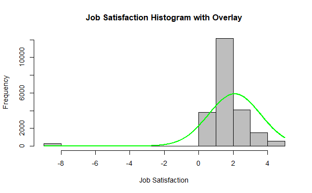

```r
# Plotting Histogram with Overlay
plotNormalHistogram(employment_survey$a8g, prob = FALSE,
                    main = "Job Satisfaction Histogram with Overlay",
                    xlab = "Job Satisfaction", linecol="green")
```

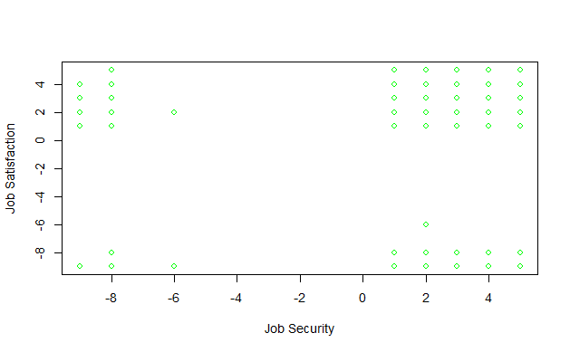

```r
# Plotting the dependent variable with the selected independent variables
plot(employment_survey$a8f,employment_survey$a8g, xlab="Job Security", ylab="Job Satisfaction", col="green") # Job security
```

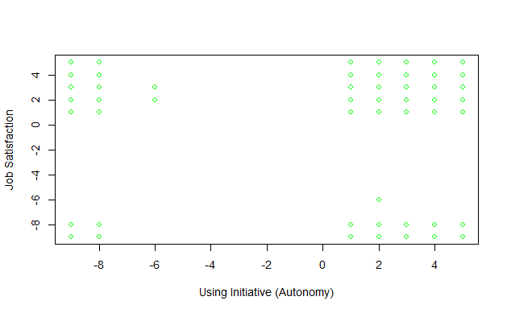

```r
plot(employment_survey$a8b,employment_survey$a8g, xlab="Using Initiative (Autonomy)", ylab="Job Satisfaction", col="green") # Using Initiative (Autonomy)
```

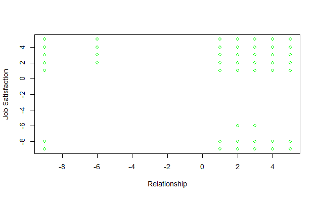

```r
plot(employment_survey$c3,employment_survey$a8g, xlab="Relationship", ylab="Job Satisfaction", col="green") # Relationship
```

From the sample dataset, median value is 2, indicating that a significant number of employees are satisfied with their job. The distribution is also skewed to the left with a negative value of -4.32.

# Distribution by gender and Age

```r
# Job Satisfaction by Gender
length(employment_survey$a8g) # Variable length
```

```
[1] 22451
```

```r
job_satisfaction_male <- length(employment_survey$a8g[employment_survey$e1 == 1])
job_satisfaction_male
```

```
[1] 10383
```

```r
job_satisfaction_female <- length(employment_survey$a8g[employment_survey$e1 == 2])
job_satisfaction_female
```

```
[1] 11962
```

```r
job_satisfaction_notAnswered <- length(employment_survey$a8g[employment_survey$e1 == -9])
job_satisfaction_notAnswered
```

```
[1] 106
```

```r
percentage_male <- job_satisfaction_male / length(employment_survey$a8g_length)
percentage_male
```

```
[1] Inf
```

```r
percentage_female <- job_satisfaction_female / length(employment_survey$a8g_length)
percentage_female
```

```
[1] Inf
```

```r
percentage_notAnswered  <- job_satisfaction_notAnswered  / length(employment_survey$a8g_length)
percentage_notAnswered
```

```
[1] Inf
```

```r
# Mean distribution
tapply(employment_survey$a8g, employment_survey$e1, summary)
```

```
$`-9`
   Min. 1st Qu.  Median    Mean 3rd Qu.    Max.
 -9.000   1.000   2.000  -0.217   2.000   4.000

$`1`
   Min. 1st Qu.  Median    Mean 3rd Qu.    Max.
 -9.000   2.000   2.000   2.185   3.000   5.000

$`2`
   Min. 1st Qu.  Median    Mean 3rd Qu.    Max.
 -9.000   2.000   2.000   2.025   2.000   5.000
```

```r
tapply(employment_survey$a8g, employment_survey$e2, summary)
```

```
$`-9`
   Min. 1st Qu.  Median    Mean 3rd Qu.    Max.
-9.0000  1.0000  2.0000 -0.4831  2.0000  4.0000

$`1`
   Min. 1st Qu.  Median    Mean 3rd Qu.    Max.
  -9.00    2.00    2.00    2.09    3.00    5.00

$`2`
   Min. 1st Qu.  Median    Mean 3rd Qu.    Max.
 -9.000   2.000   2.000   2.224   3.000   5.000

$`3`
   Min. 1st Qu.  Median    Mean 3rd Qu.    Max.
 -9.000   2.000   2.000   2.172   3.000   5.000

$`4`
   Min. 1st Qu.  Median    Mean 3rd Qu.    Max.
 -9.000   2.000   2.000   2.243   3.000   5.000

$`5`
   Min. 1st Qu.  Median    Mean 3rd Qu.    Max.
 -9.000   2.000   2.000   2.156   3.000   5.000

$`6`
   Min. 1st Qu.  Median    Mean 3rd Qu.    Max.
  -9.00    2.00    2.00    2.09    3.00    5.00

$`7`
   Min. 1st Qu.  Median    Mean 3rd Qu.    Max.
  -9.00    2.00    2.00    2.02    2.00    5.00

$`8`
   Min. 1st Qu.  Median    Mean 3rd Qu.    Max.
 -9.000   1.000   2.000   1.717   2.000   5.000

$`9`
   Min. 1st Qu.  Median    Mean 3rd Qu.    Max.
 -9.000   1.000   2.000   1.308   2.000   4.000
```

The result shows that that female respondents represented 53.3% of the votes, men 46.2% and the rest unanswered. It also shows the median job satisfaction for male and female is equal. However, the mean for male is slightly higher than that of female.

In the case of Age, the mean job satisfaction is higher for employees with ages 22-29 (4), followed by 18-19 (2) and lowest for employees at 65 and above (9). This is not surprising. Possible explanation for this could be that workers at 22-26 are relatively fresh in the workforce and thus would be more interested in building a career.However, the latter are close to retirement and most likely, diminished excitement.

# PART 2 - REGRESSION ANALYSIS

## 2.1 Calculating Correlation

```r
cor(employment_survey$a8g, employment_survey$a8f)
```

```
[1] 0.4369962
```

```r
cor(employment_survey$a8g, employment_survey$a8b)
```

```
[1] 0.5762109
```

```r
cor(employment_survey$a8g, employment_survey$c3)
```

```
[1] 0.2025141
```

The correlation coefficient for job satisfaction and job security is 0.44, job satisfaction and using initiative (autonomy) = 0.58, and job satisfaction and relationship = 0.2 respectively. While the coefficients does not suggest a strong relationship (employer-employee) between the outcome and explanatory variables, it is however, not uncommon in regression analysis. Uncorrelated variables can solve the challenge of duplication.

## 2.2 Regression of Job Satisfaction on job security, using initiative (autonomy) and relationship (employer-employee)

```r
# First Regressing Job Satisfaction on using initiative (autonomy)
lin_reg <- lm(a8g ~ a8b, data=employment_survey)
summary(lin_reg)
```

```
Call:
lm(formula = a8g ~ a8b, data = employment_survey)

Residuals:
     Min       1Q   Median       3Q      Max
-12.7408  -0.4963  -0.0574   0.5037   9.1148

Coefficients:
            Estimate Std. Error t value Pr(>|t|)
(Intercept) 0.935222   0.013712    68.2   <2e-16 ***
a8b         0.561112   0.005312   105.6   <2e-16 ***
---
Signif. codes:  0 ‘***’ 0.001 ‘**’ 0.01 ‘*’ 0.05 ‘.’ 0.1 ‘ ’ 1

Residual standard error: 1.243 on 22449 degrees of freedom
Multiple R-squared:  0.332, Adjusted R-squared:  0.332
F-statistic: 1.116e+04 on 1 and 22449 DF,  p-value: < 2.2e-16
```

```r
# Adding one variable
mul_regression1 <- lm(a8g ~ a8b + a8f,  data=employment_survey) # using initiative (autonomy) + job security
summary(mul_regression1)
```

```
Call:
lm(formula = a8g ~ a8b + a8f, data = employment_survey)

Residuals:
     Min       1Q   Median       3Q      Max
-12.5416  -0.4176  -0.0384   0.4288   9.5295

Coefficients:
            Estimate Std. Error t value Pr(>|t|)
(Intercept) 0.724850   0.013902   52.14   <2e-16 ***
a8b         0.467231   0.005481   85.24   <2e-16 ***
a8f         0.189568   0.004152   45.66   <2e-16 ***
---
Signif. codes:  0 ‘***’ 0.001 ‘**’ 0.01 ‘*’ 0.05 ‘.’ 0.1 ‘ ’ 1

Residual standard error: 1.189 on 22448 degrees of freedom
Multiple R-squared:  0.3888,    Adjusted R-squared:  0.3887
F-statistic:  7140 on 2 and 22448 DF,  p-value: < 2.2e-16
```

```r
# Adding 2 more variables
mul_regression2 <- lm(a8g ~ a8b + a8f + c3,  data=employment_survey) # using initiative (autonomy) + job security + relationship (employer-employee)
summary(mul_regression2)
```

```
Call:
lm(formula = a8g ~ a8b + a8f + c3, data = employment_survey)

Residuals:
     Min       1Q   Median       3Q      Max
-12.5536  -0.4455  -0.0271   0.4277   9.3211

Coefficients:
            Estimate Std. Error t value Pr(>|t|)
(Intercept) 0.627457   0.015710   39.94   <2e-16 ***
a8b         0.454805   0.005542   82.06   <2e-16 ***
a8f         0.185930   0.004145   44.86   <2e-16 ***
c3          0.059102   0.004500   13.13   <2e-16 ***
---
Signif. codes:  0 ‘***’ 0.001 ‘**’ 0.01 ‘*’ 0.05 ‘.’ 0.1 ‘ ’ 1

Residual standard error: 1.184 on 22447 degrees of freedom
Multiple R-squared:  0.3935,    Adjusted R-squared:  0.3934
F-statistic:  4854 on 3 and 22447 DF,  p-value: < 2.2e-16
```

```r
stargazer(lin_reg, mul_regression1, mul_regression2, title=" Regression Results", type = 'text')
```

```
Regression Results
===========================================================================================================
                                                      Dependent variable:
                    ---------------------------------------------------------------------------------------
                                                              a8g
                                 (1)                          (2)                          (3)
-----------------------------------------------------------------------------------------------------------
a8b                           0.561***                      0.467***                     0.455***
                               (0.005)                      (0.005)                      (0.006)

a8f                                                         0.190***                     0.186***
                                                            (0.004)                      (0.004)

c3                                                                                       0.059***
                                                                                         (0.005)

Constant                      0.935***                      0.725***                     0.627***
                               (0.014)                      (0.014)                      (0.016)

-----------------------------------------------------------------------------------------------------------
Observations                   22,451                        22,451                       22,451
R2                              0.332                        0.389                        0.393
Adjusted R2                     0.332                        0.389                        0.393
Residual Std. Error      1.243 (df = 22449)            1.189 (df = 22448)           1.184 (df = 22447)
F Statistic         11,158.240*** (df = 1; 22449) 7,139.568*** (df = 2; 22448) 4,853.573*** (df = 3; 22447)
===========================================================================================================
Note:                                                                           *p<0.1; **p<0.05; ***p<0.01
```

```r
stargazer(lin_reg, mul_regression1, mul_regression2, title=" Regression Models", type = 'text', dep.var.labels=c("Job Satisfaction"), covariate.labels=c("using initiative (autonomy)",
"job security ","Relationship (employer-employee"))
```

```
Regression Models
=======================================================================================================================
                                                                  Dependent variable:
                                ---------------------------------------------------------------------------------------
                                                                   Job Satisfaction
                                             (1)                          (2)                          (3)
-----------------------------------------------------------------------------------------------------------------------
using initiative (autonomy)               0.561***                      0.467***                     0.455***
                                           (0.005)                      (0.005)                      (0.006)

job security                                                            0.190***                     0.186***
                                                                        (0.004)                      (0.004)

Relationship (employer-employee                                                                      0.059***
                                                                                                     (0.005)

Constant                                  0.935***                      0.725***                     0.627***
                                           (0.014)                      (0.014)                      (0.016)

-----------------------------------------------------------------------------------------------------------------------
Observations                               22,451                        22,451                       22,451
R2                                          0.332                        0.389                        0.393
Adjusted R2                                 0.332                        0.389                        0.393
Residual Std. Error                  1.243 (df = 22449)            1.189 (df = 22448)           1.184 (df = 22447)
F Statistic                     11,158.240*** (df = 1; 22449) 7,139.568*** (df = 2; 22448) 4,853.573*** (df = 3; 22447)
=======================================================================================================================
Note:                                                                                       *p<0.1; **p<0.05; ***p<0.01
```

## 2.2.1 Extracting R-Squared Values from Models and Calculating Computing with Akaike

information criterion (AIC)

```r
# R-Squared
summary(lin_reg)$r.squared
```

```
[1] 0.332019
```

```r
summary(mul_regression1)$adj.r.squared
```

```
[1] 0.3887354
```

```r
summary(mul_regression2)$adj.r.squared
```

```
[1] 0.3933698
```

```r
# Computing with Akaike information criterion
AIC(lin_reg)
```

```
[1] 73476.3
```

```r
AIC(mul_regression1)
```

```
[1] 71484.23
```

```r
AIC(mul_regression2)
```

```
[1] 71314.36
```

Following regression analysis, results of all three models suggest statistical significance between the dependent and explanatory variables with p-values less than 0.05. Additionally, as more explanatory variables were added, the r-square continually increased, albeit slightly. That is, the values increased from 0.33 in Model 1 (lin_reg) to 0.38 in Model 2 (mul_regression1) and 0.39 in Model 3 (mul_regression2). However,the difference in Model 2 and Model 3 is negligible as they both fit the data. To explicate and choose the right model, Akaike Information Criterion (AIC) was computed to know if adding another explanatory variable in Model 3 was necessary because of the negligible increase in r-square. From the AIC test, it shows Model 3 has a lower AIC score, meaning that the additional variable added in Model 3 improved the model. Hence signifying a better fit.

## 2.3 Running Robust Estimation Tests

2.3.1 Measuring F- Test (Evauate the significance of the overall model)

```r
anova(mul_regression2, lin_reg)
```

```
Analysis of Variance Table

Model 1: a8g ~ a8b + a8f + c3
Model 2: a8g ~ a8b
  Res.Df   RSS Df Sum of Sq      F    Pr(>F)
1  22447 31483
2  22449 34672 -2   -3188.7 1136.7 < 2.2e-16 ***
---
Signif. codes:  0 ‘***’ 0.001 ‘**’ 0.01 ‘*’ 0.05 ‘.’ 0.1 ‘ ’ 1
```

2.3.2 Running RESET Test to (Evaluate Model Adequacy)

```r
resettest(mul_regression2)
```

```
    RESET test

data:  mul_regression2
RESET = 1016.4, df1 = 2, df2 = 22445, p-value < 2.2e-16
```

2.3.3 Performing Robustness Test - Estimating Heteroskedasticity - Robust Standard Error

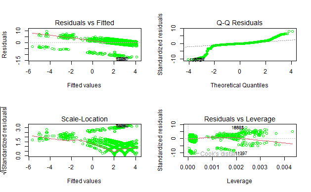

```r
# creating residual vs. fitted plot to check for Heteroskedasticity
par(mfrow=c(2,2)) # init 4 charts in 1 panel
plot(mul_regression2,  col = "green")
```

```r
# Testing Heteroskedasticity significance using ols_test_breusch_pagan Test
install.packages("olsrr", repos = "https://cloud.r-project.org")
```

```
Error in install.packages : Updating loaded packages
```

```r
library(olsrr)
ols_test_breusch_pagan(mul_regression2)
```

```
 Breusch Pagan Test for Heteroskedasticity
 -----------------------------------------
 Ho: the variance is constant
 Ha: the variance is not constant

             Data
 -------------------------------
 Response : a8g
 Variables: fitted values of a8g

        Test Summary
 -----------------------------
 DF            =    1
 Chi2          =    23060.5259
 Prob > Chi2   =    0.0000
```

```r
# Calculating Robust Standard Errors (addressing the Heteroskedasticity issues)
coeftest(mul_regression2, vcov=vcovHC(mul_regression2, "HC1"))
```

```
t test of coefficients:

             Estimate Std. Error t value  Pr(>|t|)
(Intercept) 0.6274572  0.0376054 16.6853 < 2.2e-16 ***
a8b         0.4548054  0.0176769 25.7287 < 2.2e-16 ***
a8f         0.1859297  0.0115680 16.0728 < 2.2e-16 ***
c3          0.0591022  0.0061621  9.5913 < 2.2e-16 ***
---
Signif. codes:  0 ‘***’ 0.001 ‘**’ 0.01 ‘*’ 0.05 ‘.’ 0.1 ‘ ’ 1
```

```r
stargazer(mul_regression2, coeftest(mul_regression2, vcov=vcovHC), title="Robust Standard Errors for Models", type = 'text', dep.var.labels=c("Job Satisfaction"), covariate.labels=c("using initiative (autonomy)", "job security ","Relationship (employer-employee"))
```

```
Robust Standard Errors for Models
========================================================================
                                          Dependent variable:
                                ----------------------------------------
                                      Job Satisfaction
                                            OLS              coefficient
                                                                test
                                            (1)                  (2)
------------------------------------------------------------------------
using initiative (autonomy)               0.455***            0.455***
                                          (0.006)              (0.018)

job security                              0.186***            0.186***
                                          (0.004)              (0.012)

Relationship (employer-employee           0.059***            0.059***
                                          (0.005)              (0.006)

Constant                                  0.627***            0.627***
                                          (0.016)              (0.038)

------------------------------------------------------------------------
Observations                               22,451
R2                                         0.393
Adjusted R2                                0.393
Residual Std. Error                  1.184 (df = 22447)
F Statistic                     4,853.573*** (df = 3; 22447)
========================================================================
Note:                                        *p<0.1; **p<0.05; ***p<0.01
```

Having earlier established that the coefficients of all the explanatory variables in the model are significant in explaining Job satisfaction from the p-values (2e-16 ~ 0), the p-value from the F-test also suggests statistical significance. Meaning that, the null hypothesis should be rejected with a level of confidence, and the Model (mul_regression2) be accepted.

From the robustness test, the standard errors generated are more than the standard errors of the original model suggesting that the latter was underestimated as a consequence of the heteroskedasticity.The former represents the most reliable estimates of the standard errors of the regression coefficients.

# PART 3 - CAUSAL INFERENCE

```r
mul_regression2 <- lm(a8g ~ a8b + a8f + c3,  data=employment_survey) # using initiative (autonomy) + job security + relationship (employer-employee)
summary(mul_regression2)
```

[output not shown]

Omitted variable bias could arise if there are other important factors influencing job satisfaction that are not included in the analysis. These factors could correlate with one or more of the independent variables and also affect job satisfaction, leading to biased estimates of their effects.

# Bibliography

Alegre, F., Mas-Machuca, M. and Berbegal-Miraben, J. (2016) “Antecedents of Employee Job Satisfaction: Do they Matter?”, Journal of Business Research, 69, pp. 1390-1395.

Cornelißen, T. (2006) “Job Characteristics as Determinants of Job Satisfaction and Labour Mobility” Diskussionsbeitrag, No. 334, Universität Hannover, Wirtschaftswissenschaftliche Fakultät, Hannover. Available at: http://hdl.handle.net/10419/22446 (Accessed: 3 March 2024).

Hlavac, M. (2022) “Stargazer: Well-Formatted Regression and Summary Statistics Tables”, R package version 5.2.3. https://CRAN.R-project.org/package=stargazer

Kim, L., Pimlapas, P., Siwarit, P., Ngachonpam, H. and Vikas, K. (2023) “Key Determinants of Job Satisfaction among University Lecturers”, Social Sciences, 12, 153, pp. 1-16. https://doi.org/ 10.3390/socsci12030153.

Lee et al. (2023) “Exploring Determinants of Job Satisfaction: A Comparison Between Survey and Review Data”, SAGE Open. https://doi.org/10.1177/21582440231216528

Meier, L.L. and Spector, P.E. (2015) “Job Satisfaction. In Wiley Encyclopedia of Management (eds C.L. Cooper, D.E. Guest and D.J. Needle). https://doi.org/10.1002/9781118785317.weom050093.

Pablo, J. M. (2023) “Continuing Professional Development: An Overlooked Determinant of Job Satisfaction”, International Journal of Management and Development Studies, 12(3), pp. 01-15. DOI: 10.53983/ijmds.v12n03.001

Sainju, B., Hartwell, C. and Edwards, J. (2021) “Job Satisfaction and Employee Turnover Determinants in Fortune 50 Companies: Insights from Employee Reviews from Indeed.Com”, Decision Support Systems, 148, 113582. https://doi.org/10.1016/j.dss.2021.113582.

Stokes, L. and Forth, J. (2008) Workplace Employment Relations Survey, 2004: Teaching Dataset, [data collection], Department of Trade and Industry, Employment Market Analysis and Research, 2nd Edition, Department of Trade and Industry, Employment Market Analysis and Research, [original data producer(s)]. Available at: DOI: http://doi.org/10.5255/UKDA-SN-5897-1 (Accessed: 3 March 2024).